# Do Daily AI Users Earn More Than Non-Users?

### Naive OLS → Propensity Score Matching (PSM) | Stack Overflow Developer Survey 2025

**Research question:** Does intensive (daily) use of AI coding tools increase developer salary compared to non-users?

- **D (Treatment):** `AISelect` - Daily AI user (1) vs. Non-user (0)
- **Y (Outcome):** `ConvertedCompYearly` - Annual salary in USD (log-transformed)
- **X (Covariates):** `WorkExp`, `YearsCode`, `Age`, `DevType`, `Country`, `OrgSize`, `EdLevel`, `RemoteWork`, `Employment`

Workflow (Lec 3-4 methodology):

1. Load & clean data
2. Inspect AISelect distribution → motivate treatment definition
3. Naive OLS (biased baseline)
4. Logit propensity score model
5. Nearest-neighbor PSM
6. Covariate balance check (Love Plot / SMD)
7. ATT in matched sample
8. Compare OLS vs. PSM estimates

## 1. Setup & Imports

```python
import pandas as pd
import numpy as np
import statsmodels.api as sm
import statsmodels.formula.api as smf
import matplotlib.pyplot as plt
import seaborn as sns
from sklearn.neighbors import NearestNeighbors

pd.set_option('display.max_columns', 50)
sns.set_style("whitegrid")
```

## 2. Load Data

Place `survey_results_public.csv` (Stack Overflow 2025) in the same folder as this notebook.

```python
df_raw = pd.read_csv("survey_results_public.csv", low_memory=False)
print(f"Raw shape: {df_raw.shape}")
```

```
Raw shape: (49191, 172)
```

## 3. Inspect AISelect Distribution

**Why we look before defining treatment:** In 2025, near-universal AI adoption means a binary Yes/No treatment would violate the overlap condition (P(D=1|X) ≈ 1 for most covariate profiles). We inspect the distribution first to make a data-informed, methodologically sound treatment definition.

```python
# Show full AISelect distribution
ai_dist = df_raw['AISelect'].value_counts(dropna=False)
print(ai_dist)
```

```
AISelect
Yes, I use AI tools daily                      15883
NaN                                            15471
Yes, I use AI tools weekly                      5958
No, and I don't plan to                         5454
Yes, I use AI tools monthly or infrequently     4628
No, but I plan to soon                          1797
Name: count, dtype: int64
```

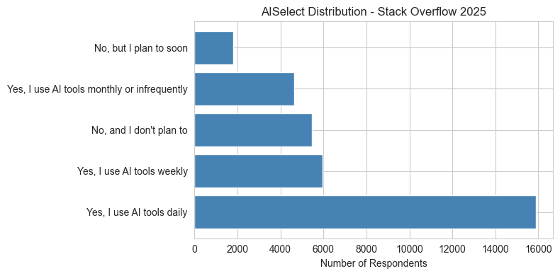

```python
# Visualise AI adoption to motivate the binary treatment definition (Daily vs. Non-user)
fig, ax = plt.subplots(figsize=(8, 4))
ai_dist_clean = df_raw['AISelect'].value_counts()
ax.barh(ai_dist_clean.index, ai_dist_clean.values, color='steelblue')
ax.axvline(0, color='black', linewidth=0.5)
ax.set_xlabel('Number of Respondents')
ax.set_title('AISelect Distribution - Stack Overflow 2025')
plt.tight_layout()
plt.show()
```

**Treatment definition (motivated by the data):**

- **Treated (D=1):** `"Yes, I use AI tools daily"` - intensive users (~15.8k)
- **Control (D=0):** Respondents who answered `No` or don't plan to use - non-users (~7k)
- **Dropped:** Weekly, monthly, NA - intermediate groups create ambiguous counterfactuals

## 4. Select Variables & Clean

We select 13 variables from the 172 available columns. The selection follows the DAG logic: only variables that simultaneously affect both salary (Y) and AI tool adoption (D) qualify as confounders (X) and must be controlled for.

**Cleaning steps:**

- **MainBranch filter:** keep only "I am a developer by profession"
- **AISelect filter:** keep only Daily users (D=1) and Non-users (D=0). Weekly and Monthly users are dropped because they represent an ambiguous intermediate treatment
- **ConvertedCompYearly:** drop missing (~30% of sample, flagged as limitation) and top/bottom 1% outliers
- **log(salary):** standard in labour economics (salary is right-skewed)
- **WorkExp / YearsCode:** text values ("Less than 1 year", "More than 50 years") converted to numeric (0.5 and 51)
- **Remaining NAs in covariates:** listwise deletion

```python
cols = ['ResponseId', 'MainBranch', 'AISelect', 'ConvertedCompYearly',
        'WorkExp', 'YearsCode', 'Age', 'DevType', 'Country',
        'OrgSize', 'EdLevel', 'RemoteWork', 'Employment']
df = df_raw[cols].copy()

# Filter: professional developers only
df = df[df['MainBranch'] == 'I am a developer by profession']

# Filter: keep only Daily users and Non-users (drop Weekly, Monthly, NA)
daily_mask = df['AISelect'] == 'Yes, I use AI tools daily'
no_mask    = df['AISelect'].str.startswith('No', na=False)
df = df[daily_mask | no_mask].copy()

# Binary treatment
df['treat'] = daily_mask[df.index].astype(int)
print("Step 1 - After MainBranch + AISelect filter (before salary & covariate cleaning):")
print(df['treat'].value_counts())
print(f"Subtotal: {len(df):,} rows\n")

# Drop missing salary & extreme outliers (top/bottom 1%)
df = df.dropna(subset=['ConvertedCompYearly'])
low, high = df['ConvertedCompYearly'].quantile([0.01, 0.99])
df = df[(df['ConvertedCompYearly'] >= low) & (df['ConvertedCompYearly'] <= high)]

# Log salary
df['log_salary'] = np.log(df['ConvertedCompYearly'])
print(f"Step 2 - After dropping missing salary & outliers: {len(df):,} rows\n")

# Clean WorkExp & YearsCode
def clean_years(x):
    if pd.isna(x): return np.nan
    if str(x) == 'Less than 1 year': return 0.5
    if str(x) == 'More than 50 years': return 51.0
    try: return float(x)
    except: return np.nan

df['WorkExp']   = df['WorkExp'].apply(clean_years)
df['YearsCode'] = df['YearsCode'].apply(clean_years)

# Drop rows with missing covariates
covariates = ['WorkExp', 'YearsCode', 'Age', 'DevType', 'Country',
              'OrgSize', 'EdLevel', 'RemoteWork', 'Employment']
df = df.dropna(subset=covariates)

print(f"Step 3 - After dropping missing covariates: {len(df):,} rows\n")
print("Final cleaned sample - Treatment distribution:")
print(df['treat'].value_counts())
print(f"Total: {df.shape[0]:,} rows × {df.shape[1]} columns\n")

df[['treat', 'AISelect', 'ConvertedCompYearly', 'log_salary',
    'WorkExp', 'YearsCode', 'Age', 'DevType', 'Country',
    'OrgSize', 'EdLevel', 'RemoteWork', 'Employment']].head(10)

# Save cleaned dataset
df.to_csv("so_2025_cleaned.csv", index=False)
print("Cleaned data saved to so_2025_cleaned.csv")
```

```
Step 1 - After MainBranch + AISelect filter (before salary & covariate cleaning):
treat
1    13191
0     5011
Name: count, dtype: int64
Subtotal: 18,202 rows

Step 2 - After dropping missing salary & outliers: 13,422 rows

Step 3 - After dropping missing covariates: 11,760 rows

Final cleaned sample - Treatment distribution:
treat
1    8687
0    3073
Name: count, dtype: int64
Total: 11,760 rows × 15 columns

Cleaned data saved to so_2025_cleaned.csv
```

```python
print(f"\nCleaned dataset: {df.shape[0]:,} rows × {df.shape[1]} columns")
print(f"Treated (Daily): {df['treat'].sum():,} | Control (Non-user): {(df['treat']==0).sum():,}")
print()
df[['treat', 'AISelect', 'ConvertedCompYearly', 'log_salary',
    'WorkExp', 'YearsCode', 'Age', 'DevType', 'Country',
    'OrgSize', 'EdLevel', 'RemoteWork', 'Employment']].head(10)
```

```
Cleaned dataset: 11,760 rows × 15 columns
Treated (Daily): 8,687 | Control (Non-user): 3,073
```

|  | treat | AISelect | ConvertedCompYearly | log_salary | WorkExp | YearsCode | Age | DevType | Country | OrgSize | EdLevel | RemoteWork | Employment |
| --- | --- | --- | --- | --- | --- | --- | --- | --- | --- | --- | --- | --- | --- |
| 7 | 1 | Yes, I use AI tools daily | 72000.0 | 11.184421 | 22.0 | 30.0 | 35-44 years old | Architect, software or solutions | Ukraine | Less than 20 employees | Professional degree (JD, MD, Ph.D, Ed.D, etc.) | Remote | Employed |
| 9 | 0 | No, and I don't plan to | 5400.0 | 8.594154 | 7.0 | 10.0 | 25-34 years old | Developer, mobile | Ukraine | 20 to 99 employees | Master’s degree (M.A., M.S., M.Eng., MBA, etc.) | Remote | Employed |
| 10 | 1 | Yes, I use AI tools daily | 65691.0 | 11.092717 | 7.0 | 9.0 | 25-34 years old | Developer, back-end | Ukraine | 100 to 499 employees | Master’s degree (M.A., M.S., M.Eng., MBA, etc.) | Remote | Employed |
| 11 | 1 | Yes, I use AI tools daily | 14400.0 | 9.574983 | 3.0 | 5.0 | 18-24 years old | Developer, back-end | Ukraine | 100 to 499 employees | Bachelor’s degree (B.A., B.S., B.Eng., etc.) | Remote | Employed |
| 27 | 1 | Yes, I use AI tools daily | 209643.0 | 12.253161 | 24.0 | 36.0 | 45-54 years old | Developer, full-stack | Sweden | 1,000 to 4,999 employees | Bachelor’s degree (B.A., B.S., B.Eng., etc.) | Hybrid (some remote, leans heavy to in-person) | Employed |
| 29 | 1 | Yes, I use AI tools daily | 205000.0 | 12.230765 | 19.0 | 15.0 | 35-44 years old | Developer, mobile | United States of America | 500 to 999 employees | Master’s degree (M.A., M.S., M.Eng., MBA, etc.) | Remote | Employed |
| 31 | 0 | No, and I don't plan to | 250000.0 | 12.429216 | 17.0 | 23.0 | 35-44 years old | Developer, full-stack | United States of America | 100 to 499 employees | Bachelor’s degree (B.A., B.S., B.Eng., etc.) | Remote | Employed |
| 33 | 0 | No, and I don't plan to | 175000.0 | 12.072541 | 24.0 | 26.0 | 45-54 years old | Data engineer | United States of America | 5,000 to 9,999 employees | Bachelor’s degree (B.A., B.S., B.Eng., etc.) | Hybrid (some remote, leans heavy to in-person) | Employed |
| 35 | 1 | Yes, I use AI tools daily | 95132.0 | 11.463021 | 10.0 | 10.0 | 25-34 years old | Developer, back-end | Germany | 1,000 to 4,999 employees | Bachelor’s degree (B.A., B.S., B.Eng., etc.) | Your choice (very flexible, you can come in wh... | Employed |
| 37 | 0 | No, and I don't plan to | 109000.0 | 11.599103 | 15.0 | 25.0 | 35-44 years old | Developer, full-stack | United States of America | 10,000 or more employees | Master’s degree (M.A., M.S., M.Eng., MBA, etc.) | In-person | Employed |

## 5. Descriptive Statistics

```python
summary = df.groupby('treat')['ConvertedCompYearly'].agg(
    N='count', Mean='mean', Median='median', Std='std'
)
summary.index = ['Non-user (D=0)', 'Daily user (D=1)']
print(summary.round(0))
```

```
                     N     Mean   Median      Std
Non-user (D=0)    3073  96818.0  83531.0  63679.0
Daily user (D=1)  8687  87744.0  74878.0  69738.0
```

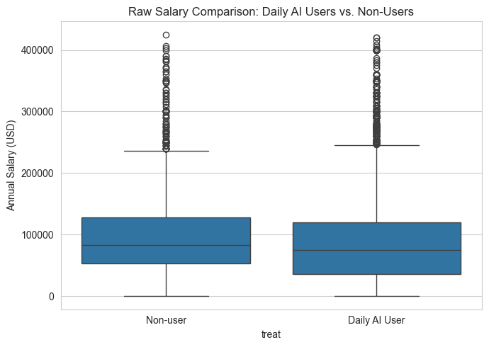

```python
fig, ax = plt.subplots(figsize=(7, 5))
sns.boxplot(x='treat', y='ConvertedCompYearly', data=df, ax=ax)
ax.set_xticks([0, 1])
ax.set_xticklabels(['Non-user', 'Daily AI User'])
ax.set_ylabel('Annual Salary (USD)')
ax.set_title('Raw Salary Comparison: Daily AI Users vs. Non-Users')
plt.tight_layout()
plt.show()
# NOTE: This raw difference is BIASED — daily users likely differ on experience, role etc.
# Propensity Score Matching will address this selection bias.
```

## 6. Naive OLS - Biased Baseline

```python
from statsmodels.iolib.summary2 import summary_col

# Naive OLS
ols_naive = smf.ols('log_salary ~ treat', data=df).fit()

# OLS with controls
ols_controls = smf.ols(
    'log_salary ~ treat + WorkExp + YearsCode + C(Age) + C(DevType) + '
    'C(Country) + C(OrgSize) + C(EdLevel) + C(RemoteWork) + C(Employment)',
    data=df
).fit()

# Koeffizienten
naive_coef = ols_naive.params['treat']
ctrl_coef  = ols_controls.params['treat']
naive_pval = ols_naive.pvalues['treat']
ctrl_pval  = ols_controls.pvalues['treat']
naive_pct  = (np.exp(naive_coef) - 1) * 100
ctrl_pct   = (np.exp(ctrl_coef)  - 1) * 100

# Generate side-by-side regression output table
table = summary_col(
    [ols_naive, ols_controls],
    model_names=['(1) Naive OLS', '(2) OLS + Controls'],
    stars=True,
    info_dict={'N': lambda x: f"{int(x.nobs):,}", 'R²': lambda x: f"{x.rsquared:.3f}"}
)
print(table)

# Calculate magnitude of coefficient shift to evaluate omitted variable bias
bias_magnitude = abs(naive_coef - ctrl_coef)
sign_flip = (naive_coef < 0) != (ctrl_coef < 0)

print(f"\nNaive OLS treatment effect:       {naive_pct:+.1f}%")
print(f"OLS with controls treatment effect: {ctrl_pct:+.1f}%")
print(f"Coefficient change when adding controls: {bias_magnitude:.4f} log points")

if sign_flip:
    print(f"\n→ Sign reversal detected (from {naive_pct:.1f}% to {ctrl_pct:.1f}%)")
    print("→ Strong empirical evidence of selection bias in naive estimate")
    print("→ Confounders (WorkExp, Country, DevType...) were driving the raw difference")
elif bias_magnitude > 0.1:
    print(f"\n→ Large coefficient shift ({bias_magnitude:.3f} log pts) when adding controls")
    print("→ Empirical evidence of omitted variable bias in naive estimate")
else:
    print("\n→ Controls change estimate only marginally - selection bias appears limited")
```

```
=================================================================================================================================
                                                                                                 (1) Naive OLS (2) OLS + Controls
---------------------------------------------------------------------------------------------------------------------------------
Intercept                                                                                        11.2002***    8.5272***
                                                                                                 (0.0216)      (0.4217)
treat                                                                                            -0.3018***    0.0649***
                                                                                                 (0.0251)      (0.0184)
C(Age)[T.25-34 years old]                                                                                      0.3947***
                                                                                                               (0.0297)
C(Age)[T.35-44 years old]                                                                                      0.3800***
                                                                                                               (0.0362)
C(Age)[T.45-54 years old]                                                                                      0.0915*
                                                                                                               (0.0499)
C(Age)[T.55-64 years old]                                                                                      -0.2275***
                                                                                                               (0.0682)
C(Age)[T.65 years or older]                                                                                    -0.5677***
                                                                                                               (0.1104)
C(Age)[T.Prefer not to say]                                                                                    0.2818
                                                                                                               (0.4164)
C(DevType)[T.Academic researcher]                                                                              -0.5261***
                                                                                                               (0.1025)
C(DevType)[T.Applied scientist]                                                                                -0.1401
                                                                                                               (0.1346)
C(DevType)[T.Architect, software or solutions]                                                                 -0.0454
                                                                                                               (0.0641)
C(DevType)[T.Cloud infrastructure engineer]                                                                    0.0931
                                                                                                               (0.0985)
C(DevType)[T.Cybersecurity or InfoSec professional]                                                            0.0901
                                                                                                               (0.1257)
C(DevType)[T.Data engineer]                                                                                    -0.2114***
                                                                                                               (0.0760)
C(DevType)[T.Data or business analyst]                                                                         -0.3646**
                                                                                                               (0.1526)
C(DevType)[T.Data scientist]                                                                                   -0.1034
                                                                                                               (0.0890)
C(DevType)[T.Database administrator or engineer]                                                               -0.1009
                                                                                                               (0.1399)
C(DevType)[T.DevOps engineer or professional]                                                                  -0.0861
                                                                                                               (0.0742)
C(DevType)[T.Developer, AI apps or physical AI]                                                                -0.1147
```

[output cut: 385 more lines]

```
R-squared                                                                                        0.0121        0.5423
R-squared Adj.                                                                                   0.0120        0.5340
N                                                                                                11,760        11,760
R²                                                                                               0.012         0.542
=================================================================================================================================
Standard errors in parentheses.
* p<.1, ** p<.05, ***p<.01

Naive OLS treatment effect:       -26.1%
OLS with controls treatment effect: +6.7%
Coefficient change when adding controls: 0.3667 log points

→ Sign reversal detected (from -26.1% to 6.7%)
→ Strong empirical evidence of selection bias in naive estimate
→ Confounders (WorkExp, Country, DevType...) were driving the raw difference
```

```python
# Illustration for presentation
table_data = {
    'Model': ['(1) Naive OLS', '(2) OLS + Controls'],
    'Treat coef.': [f"{ols_naive.params['treat']:.4f}***",
                    f"{ols_controls.params['treat']:.4f}***"],
    'SE': [f"({ols_naive.bse['treat']:.4f})",
           f"({ols_controls.bse['treat']:.4f})"],
    '% Salary Effect': [f"{naive_pct:+.1f}%", f"{ctrl_pct:+.1f}%"],
    'Controls': ['No', 'Yes'],
    'N': [f"{int(ols_naive.nobs):,}", f"{int(ols_controls.nobs):,}"],
    'R²': [f"{ols_naive.rsquared:.3f}", f"{ols_controls.rsquared:.3f}"]
}

tbl = pd.DataFrame(table_data).set_index('Model')
print(tbl.to_string())
```

```
                   Treat coef.        SE % Salary Effect Controls       N     R²
Model
(1) Naive OLS       -0.3018***  (0.0251)          -26.1%       No  11,760  0.012
(2) OLS + Controls   0.0649***  (0.0184)           +6.7%      Yes  11,760  0.542
```

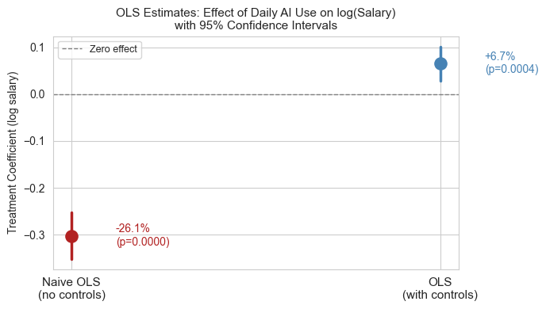

```
→ Sign reversal from -26.1% to +6.7% when controls added
→ Naive estimate was capturing seniority/experience gap, not the AI effect
→ Motivates PSM: ensure treated and control groups are truly comparable
```

```python
# Illustration
import matplotlib.pyplot as plt
import numpy as np

# Coefficients und Confidentintervalle for 'treat'
models = ['Naive OLS\n(no controls)', 'OLS\n(with controls)']
coefs  = [ols_naive.params['treat'], ols_controls.params['treat']]
cis    = [
    ols_naive.conf_int().loc['treat'].values,
    ols_controls.conf_int().loc['treat'].values
]
pcts   = [(np.exp(c) - 1) * 100 for c in coefs]

fig, ax = plt.subplots(figsize=(7, 4))

colors = ['firebrick', 'steelblue']
for i, (model, coef, ci, pct, color) in enumerate(zip(models, coefs, cis, pcts, colors)):
    ax.scatter(i, coef, color=color, s=120, zorder=3)
    ax.plot([i, i], ci, color=color, linewidth=2.5, zorder=2)
    ax.annotate(f'{pct:+.1f}%\n(p={[ols_naive, ols_controls][i].pvalues["treat"]:.4f})',
                xy=(i, coef), xytext=(i + 0.12, coef),
                fontsize=10, color=color, va='center')

ax.axhline(0, linestyle='--', color='grey', linewidth=1, label='Zero effect')
ax.set_xticks([0, 1])
ax.set_xticklabels(models, fontsize=11)
ax.set_ylabel('Treatment Coefficient (log salary)', fontsize=10)
ax.set_title('OLS Estimates: Effect of Daily AI Use on log(Salary)\nwith 95% Confidence Intervals', fontsize=11)
ax.legend(fontsize=9)
plt.tight_layout()
plt.show()

print("→ Sign reversal from -26.1% to +6.7% when controls added")
print("→ Naive estimate was capturing seniority/experience gap, not the AI effect")
print("→ Motivates PSM: ensure treated and control groups are truly comparable")
```

## 7. Step 1 of PSM - Logit Propensity Score

Estimate P(D=1 | X): probability of being a daily AI user given covariates X. This compresses all covariates into one score for efficient matching (Rosenbaum & Rubin 1983).

```python
# Group rare countries AND DevTypes to prevent perfect separation in logit
def group_rare(series, min_count=30):
    counts = series.value_counts()
    rare = counts[counts < min_count].index
    return series.replace(rare, 'Other')

df['Country_grp'] = group_rare(df['Country'], min_count=30)
df['DevType_grp'] = group_rare(df['DevType'], min_count=30)

# Covariates for propensity score model
covariates_logit = ['WorkExp', 'YearsCode', 'Age', 'DevType_grp', 'Country_grp',
                    'OrgSize', 'EdLevel', 'RemoteWork', 'Employment']

# Dummy-encode categorical variables and add constant
X = pd.get_dummies(df[covariates_logit], drop_first=True).astype(float)
X = sm.add_constant(X)
y = df['treat']

# Estimate logit model → propensity score P(D=1|X)
logit_model = sm.Logit(y, X).fit(maxiter=200, disp=False)
df['pscore'] = logit_model.predict(X)

print(f"Propensity score range: [{df['pscore'].min():.3f}, {df['pscore'].max():.3f}]")
print(f"Mean PS - treated: {df.loc[df.treat==1,'pscore'].mean():.3f}")
print(f"Mean PS - control: {df.loc[df.treat==0,'pscore'].mean():.3f}")
```

```
Propensity score range: [0.032, 1.000]
Mean PS - treated: 0.770
Mean PS - control: 0.650
```

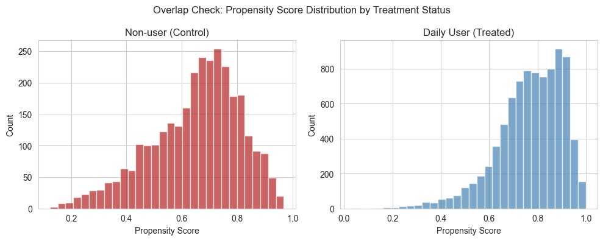

```python
# Overlap check - critical for CIA validity
fig, axes = plt.subplots(1, 2, figsize=(10, 4), sharey=False)
for ax, (grp, label) in zip(axes, [(0, 'Non-user (Control)'), (1, 'Daily User (Treated)')]):
    ax.hist(df.loc[df.treat==grp, 'pscore'], bins=30, color='steelblue' if grp else 'firebrick', alpha=0.7)
    ax.set_title(label)
    ax.set_xlabel('Propensity Score')
    ax.set_ylabel('Count')
fig.suptitle('Overlap Check: Propensity Score Distribution by Treatment Status', fontsize=12)
plt.tight_layout()
plt.show()
# Good overlap = distributions share a common support region → CIA more plausible
```

## 8. Step 2 of PSM - Nearest-Neighbor Matching (with Caliper)

For each daily user, find the non-user with the closest propensity score. Caliper = 0.1 SD to avoid bad matches.

```python
# Caliper in standard deviations of PS (course convention: 0.25 SD)
ps_sd = df['pscore'].std()
caliper = 0.1 * ps_sd
print(f"PS standard deviation: {ps_sd:.4f}")
print(f"Caliper (0.25 SD): {caliper:.4f}")

# Split into treated and control
treated = df[df['treat'] == 1].copy().reset_index(drop=True)
control = df[df['treat'] == 0].copy().reset_index(drop=True)

# Nearest-neighbor matching WITH replacement
# Replacement is necessary given the 3:1 treated-to-control ratio
# Without replacement, many treated units would receive poor matches
nn = NearestNeighbors(n_neighbors=1)
nn.fit(control[['pscore']])
distances, indices = nn.kneighbors(treated[['pscore']])

treated['match_distance'] = distances.flatten()
treated['match_ctrl_idx'] = indices.flatten()

# Apply caliper - drop treated units without a sufficiently close control match
treated_matched  = treated[treated['match_distance'] <= caliper].copy()
matched_controls = control.iloc[treated_matched['match_ctrl_idx'].values].copy()

print(f"\nTreated before caliper: {len(treated):,}")
print(f"Treated after caliper:  {len(treated_matched):,}")
print(f"Caliper drop rate:      {(1 - len(treated_matched)/len(treated))*100:.1f}%")
print(f"\nUnique controls used:   {len(set(treated_matched['match_ctrl_idx'])):,}")
print(f"Total controls available: {len(control):,}")
print(f"Average times a control is reused: {len(treated_matched)/len(set(treated_matched['match_ctrl_idx'])):.1f}x")

# Assign matching weights - controls used multiple times get proportionally higher weight
from collections import Counter
ctrl_counts = Counter(treated_matched['match_ctrl_idx'].values)
matched_controls = matched_controls.copy()
matched_controls['weight'] = [ctrl_counts[i] for i in treated_matched['match_ctrl_idx'].values]
treated_matched['weight'] = 1

# Build matched dataset
matched_data = pd.concat([treated_matched, matched_controls], axis=0).reset_index(drop=True)
print(f"\nFinal matched sample: {len(matched_data):,} rows")
```

```
PS standard deviation: 0.1525
Caliper (0.25 SD): 0.0153

Treated before caliper: 8,687
Treated after caliper:  8,591
Caliper drop rate:      1.1%

Unique controls used:   2,194
Total controls available: 3,073
Average times a control is reused: 3.9x

Final matched sample: 17,182 rows
```

## 9. Step 3 of PSM - Covariate Balance Check (Love Plot)

Standardized Mean Difference (SMD) before vs. after matching. **Threshold: |SMD| < 0.1** (convention from lecture `love.plot(threshold=0.1)`).

```python
# SMD for unweighted data (before matching)
def smd(data, var, treat_col='treat'):
    t = data.loc[data[treat_col]==1, var].dropna()
    c = data.loc[data[treat_col]==0, var].dropna()
    pooled_sd = np.sqrt((t.var() + c.var()) / 2)
    return (t.mean() - c.mean()) / pooled_sd if pooled_sd > 0 else np.nan

# SMD for weighted matched sample (after matching)
def smd_weighted(data, var, treat_col='treat', weight_col='weight'):
    t = data[data[treat_col]==1]
    c = data[data[treat_col]==0]
    mean_t = np.average(t[var].dropna(), weights=t.loc[t[var].notna(), weight_col])
    mean_c = np.average(c[var].dropna(), weights=c.loc[c[var].notna(), weight_col])
    pooled_sd = np.sqrt((t[var].var() + c[var].var()) / 2)
    return (mean_t - mean_c) / pooled_sd if pooled_sd > 0 else np.nan

# Build balance datasets including key categorical dummies
# Country and DevType excluded due to high cardinality (controlled via PS model)
dummy_vars = pd.get_dummies(
    df[['EdLevel', 'RemoteWork', 'Employment', 'Age', 'OrgSize']],
    drop_first=True).astype(float)
df_bal = pd.concat([df[['treat', 'WorkExp', 'YearsCode']], dummy_vars], axis=1)

matched_dummies = pd.get_dummies(
    matched_data[['EdLevel', 'RemoteWork', 'Employment', 'Age', 'OrgSize']],
    drop_first=True).astype(float)
matched_bal = pd.concat([
    matched_data[['treat', 'WorkExp', 'YearsCode', 'weight']],
    matched_dummies], axis=1)

# Compute SMD for all covariates
all_vars = [c for c in df_bal.columns if c != 'treat']
balance_rows = []
for var in all_vars:
    balance_rows.append({
        'variable': var,
        'SMD_before': smd(df_bal, var),
        'SMD_after':  smd_weighted(matched_bal, var)
    })

balance_tbl = pd.DataFrame(balance_rows)
print(balance_tbl.round(3))
print("\nNote: Country and DevType balance not shown individually due to high")
print("cardinality — these are controlled directly via the propensity score model.")
```

```
                                             variable  SMD_before  SMD_after
0                                             WorkExp      -0.288      0.002
1                                           YearsCode      -0.408      0.121
2   EdLevel_Bachelor’s degree (B.A., B.S., B.Eng.,...       0.044     -0.013
3   EdLevel_Master’s degree (M.A., M.S., M.Eng., M...      -0.010     -0.013
4                     EdLevel_Other (please specify):      -0.007      0.040
5                   EdLevel_Primary/elementary school       0.027     -0.004
6   EdLevel_Professional degree (JD, MD, Ph.D, Ed....      -0.071      0.041
7   EdLevel_Secondary school (e.g. American high s...       0.019     -0.047
8   EdLevel_Some college/university study without ...      -0.022     -0.022
9   RemoteWork_Hybrid (some remote, leans heavy to...      -0.034     -0.038
10                               RemoteWork_In-person      -0.004     -0.055
11                                  RemoteWork_Remote       0.087     -0.092
12  RemoteWork_Your choice (very flexible, you can...      -0.036      0.072
13  Employment_Independent contractor, freelancer,...       0.030     -0.080
```

[output cut: 20 more lines]

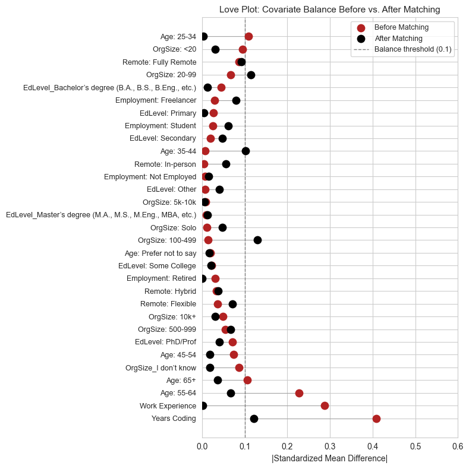

```python
# Clean variable names for display
name_map = {
    'WorkExp': 'Work Experience',
    'YearsCode': 'Years Coding',
    # EdLevel
    'EdLevel_Bachelor\'s degree (B.A., B.S., B.Eng., etc.)': 'EdLevel: Bachelor',
    'EdLevel_Master\'s degree (M.A., M.S., M.Eng., MBA, etc.)': 'EdLevel: Master',
    'EdLevel_Professional degree (JD, MD, Ph.D, Ed.D, etc.)': 'EdLevel: PhD/Prof',
    'EdLevel_Some college/university study without earning a degree': 'EdLevel: Some College',
    'EdLevel_Secondary school (e.g. American high school, German Realschule or Gymnasium, etc.)': 'EdLevel: Secondary',
    'EdLevel_Primary/elementary school': 'EdLevel: Primary',
    'EdLevel_Other (please specify):': 'EdLevel: Other',
    # RemoteWork
    'RemoteWork_Remote': 'Remote: Fully Remote',
    'RemoteWork_Hybrid (some remote, leans heavy to in-person)': 'Remote: Hybrid',
    'RemoteWork_In-person': 'Remote: In-person',
    'RemoteWork_Your choice (very flexible, you can come in when you want or just as needed)': 'Remote: Flexible',
    # Employment
    'Employment_Independent contractor, freelancer, or self-employed': 'Employment: Freelancer',
    'Employment_Not employed': 'Employment: Not Employed',
    'Employment_Retired': 'Employment: Retired',
    'Employment_Student': 'Employment: Student',
    # Age
    'Age_18-24 years old': 'Age: 18-24',
    'Age_25-34 years old': 'Age: 25-34',
    'Age_35-44 years old': 'Age: 35-44',
    'Age_45-54 years old': 'Age: 45-54',
    'Age_55-64 years old': 'Age: 55-64',
    'Age_65 years or older': 'Age: 65+',
    'Age_Prefer not to say': 'Age: Prefer not to say',
    # OrgSize
    'OrgSize_Just me - I am a freelancer, sole proprietor, etc.': 'OrgSize: Solo',
    'OrgSize_2 to 9 employees': 'OrgSize: 2-9',
    'OrgSize_10 to 19 employees': 'OrgSize: 10-19',
    'OrgSize_20 to 99 employees': 'OrgSize: 20-99',
    'OrgSize_100 to 499 employees': 'OrgSize: 100-499',
    'OrgSize_500 to 999 employees': 'OrgSize: 500-999',
    'OrgSize_1,000 to 4,999 employees': 'OrgSize: 1k-5k',
    'OrgSize_5,000 to 9,999 employees': 'OrgSize: 5k-10k',
    'OrgSize_10,000 or more employees': 'OrgSize: 10k+',
    'OrgSize_Less than 20 employees': 'OrgSize: <20',
    'OrgSize_I don\'t know': 'OrgSize: Unknown',
}

balance_tbl['label'] = balance_tbl['variable'].map(
    lambda x: name_map.get(x, x))

# Sort by SMD_before descending
balance_tbl = balance_tbl.sort_values('SMD_before', ascending=True)

fig, ax = plt.subplots(figsize=(8, 8))
y_pos = np.arange(len(balance_tbl))

ax.scatter(balance_tbl['SMD_before'].abs(), y_pos,
           label='Before Matching', color='firebrick', s=80, zorder=3)
ax.scatter(balance_tbl['SMD_after'].abs(), y_pos,
           label='After Matching', color='black', s=80, zorder=3)

# Connect before and after with a line for clarity
for i, (_, row) in enumerate(balance_tbl.iterrows()):
    ax.plot([abs(row['SMD_before']), abs(row['SMD_after'])],
            [i, i], color='grey', linewidth=0.8, alpha=0.5, zorder=2)

ax.axvline(0.1, linestyle='--', color='grey', linewidth=1,
           label='Balance threshold (0.1)')

ax.set_yticks(y_pos)
ax.set_yticklabels(balance_tbl['label'], fontsize=9)
ax.set_xlabel('|Standardized Mean Difference|', fontsize=10)
ax.set_title('Love Plot: Covariate Balance Before vs. After Matching', fontsize=11)
ax.set_xlim(0, 0.6)
ax.legend(fontsize=9)
plt.tight_layout()
plt.show()
```

Balance for Country and DevType is not assessed individually due to high cardinality, these variables are controlled directly via the propensity score model.

## 10. ATT in Matched Sample

The ATT = E[Y(1) − Y(0) | D=1]: average salary effect for daily users under the CIA assumption.

```python
# Simple mean difference
att_means = matched_data.groupby('treat')['log_salary'].mean()
att_simple = att_means[1] - att_means[0]
att_pct_simple = (np.exp(att_simple) - 1) * 100
print(f"ATT simple (log pts): {att_simple:.4f}")
print(f"ATT simple (% salary): {att_pct_simple:.1f}%")
```

```
ATT simple (log pts): 0.0448
ATT simple (% salary): 4.6%
```

```python
# Regression-based ATT on matched sample (preferred - controls for residual imbalance)
att_reg = smf.ols(
    'log_salary ~ treat + WorkExp + YearsCode + C(Age) + C(DevType) + '
    'C(Country) + C(OrgSize) + C(EdLevel) + C(RemoteWork) + C(Employment)',
    data=matched_data
).fit()

att_coef = att_reg.params['treat']
att_pval = att_reg.pvalues['treat']
att_pct  = (np.exp(att_coef) - 1) * 100
print(f"ATT regression (log pts): {att_coef:.4f} | p-value: {att_pval:.4f}")
print(f"ATT regression (% salary): {att_pct:.1f}%")
```

```
ATT regression (log pts): 0.0652 | p-value: 0.0000
ATT regression (% salary): 6.7%
```

## 11. Results Comparison

```python
results = pd.DataFrame({
    'Method': [
        'Naive OLS (no controls)',
        'OLS with controls',
        'PSM - regression on matched sample'
    ],
    'Coef. (log)': [naive_coef, ctrl_coef, att_coef],
    'p-value':     [naive_pval, ctrl_pval, att_pval],
    '% Salary Effect': [naive_pct, ctrl_pct, att_pct]
})
print(results.round(4).to_string(index=False))
```

```
                            Method  Coef. (log)  p-value  % Salary Effect
           Naive OLS (no controls)      -0.3018   0.0000         -26.0520
                 OLS with controls       0.0649   0.0004           6.7019
PSM - regression on matched sample       0.0652   0.0000           6.7376
```